# Gender Equity Dashboard

# Housing data

Our goal is to create variables for gender, age group, whether someone is a mother, whether someone is married, their level of education, their income, whether they are the head of household, and the number of children they have.

There are also variables for severe cost burden (households that pay more than half of their income towards housing) and households with severe housing problems (lacking a kitchen, adequate plumbing, or an ample number of rooms for the number of people living there).

For each category that we’ve come up with, we want to summarize the data by year, gender, the housing characteristics (like are they a homeowner or a renter?), and the other characteristics (like what is their income level?)

year | gender | homeownership | cost_burden | mother | head_of_household

#Income

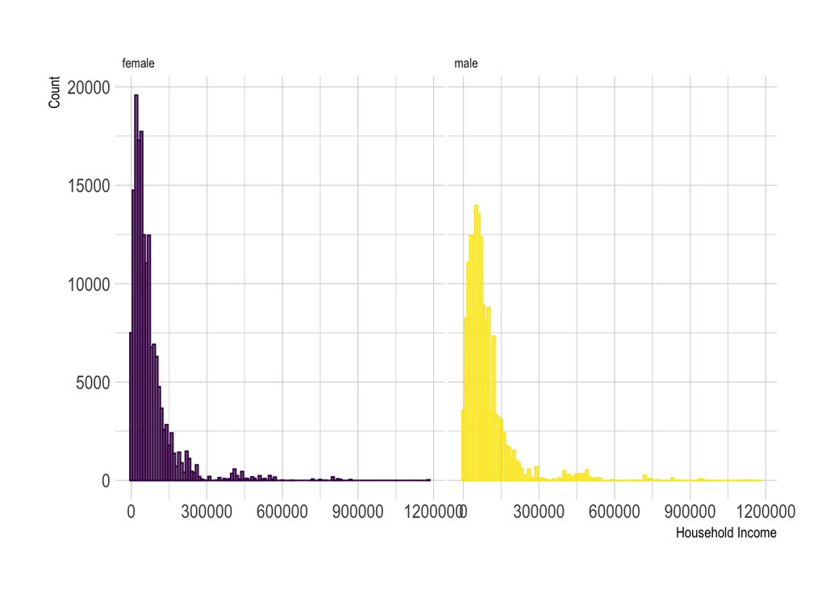

```r
#Male vs. Female income
lville_2019 %>%
  func_plt_hist_updated( "sex")
```

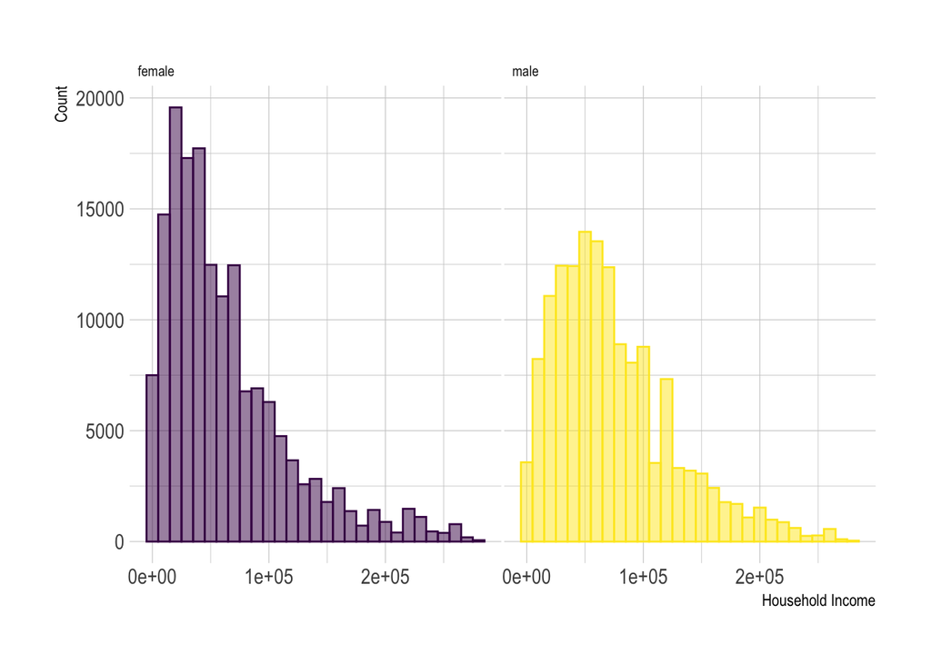

```r
#Male vs. Female income truncated
lville_2019 %>%
  filter(HHINCOME <= cut_95) %>%
  func_plt_hist_updated( "sex")
```

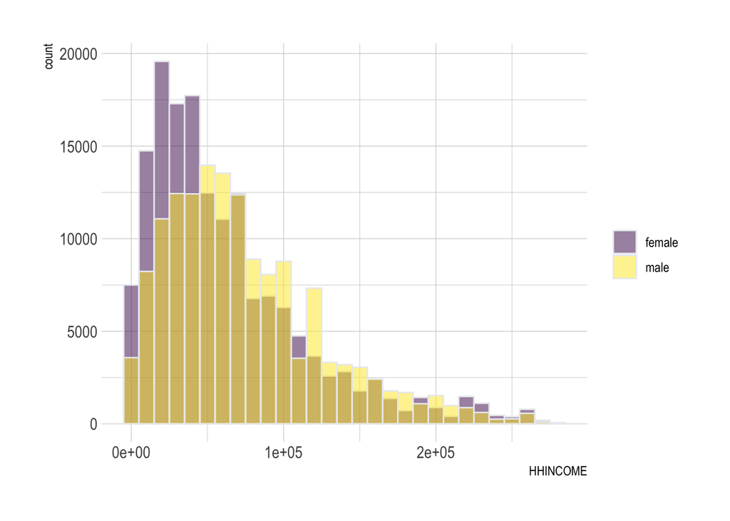

```r
#Male vs. female income truncated, overlay - unclear to look at (try different colors first before diff type of viz)
lville_2019 %>%
  filter(HHINCOME <= cut_95) %>%
        func_plt_hist_overlay( "sex")
```

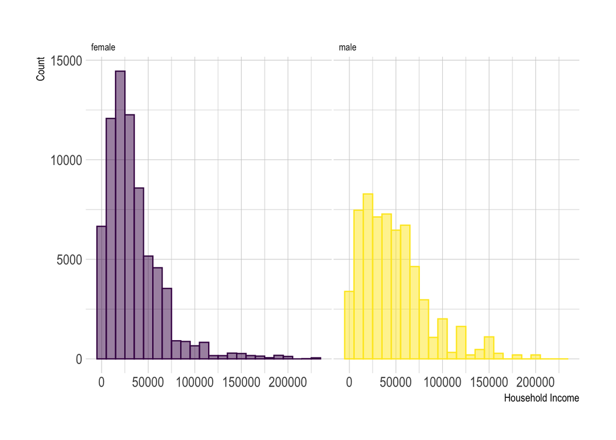

```r
#Single male vs. single female income, truncated

lville_2019 %>%
  filter(earner_type == 'single_earner',
      HHINCOME <= cut_95) %>%
        func_plt_hist_updated( "sex")
```

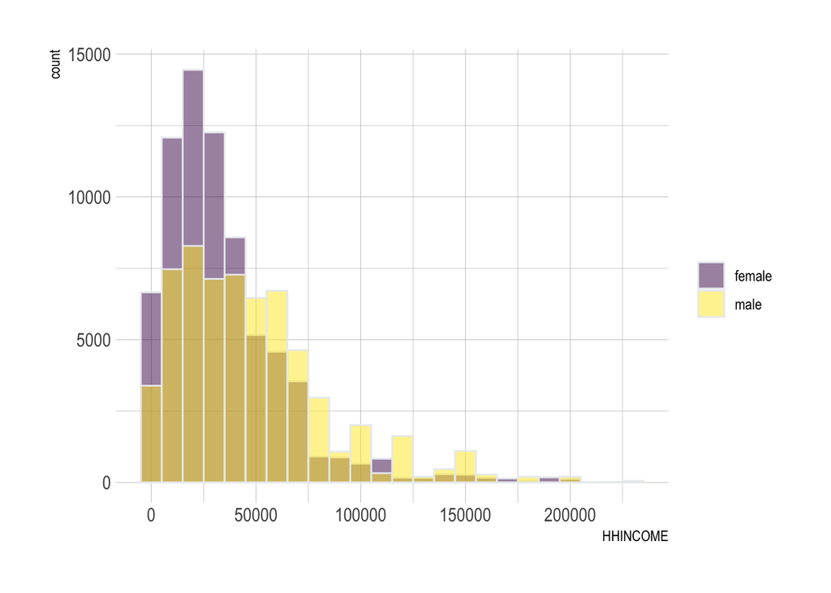

```r
#Single male vs. single female income, truncated, overlay-> might incorporate 95th percentile for each group (i.e. single male 95th - do this outside of r)
lville_2019 %>%
  filter(earner_type == 'single_earner',
      HHINCOME <= cut_95) %>%
        func_plt_hist_overlay( "sex")
```

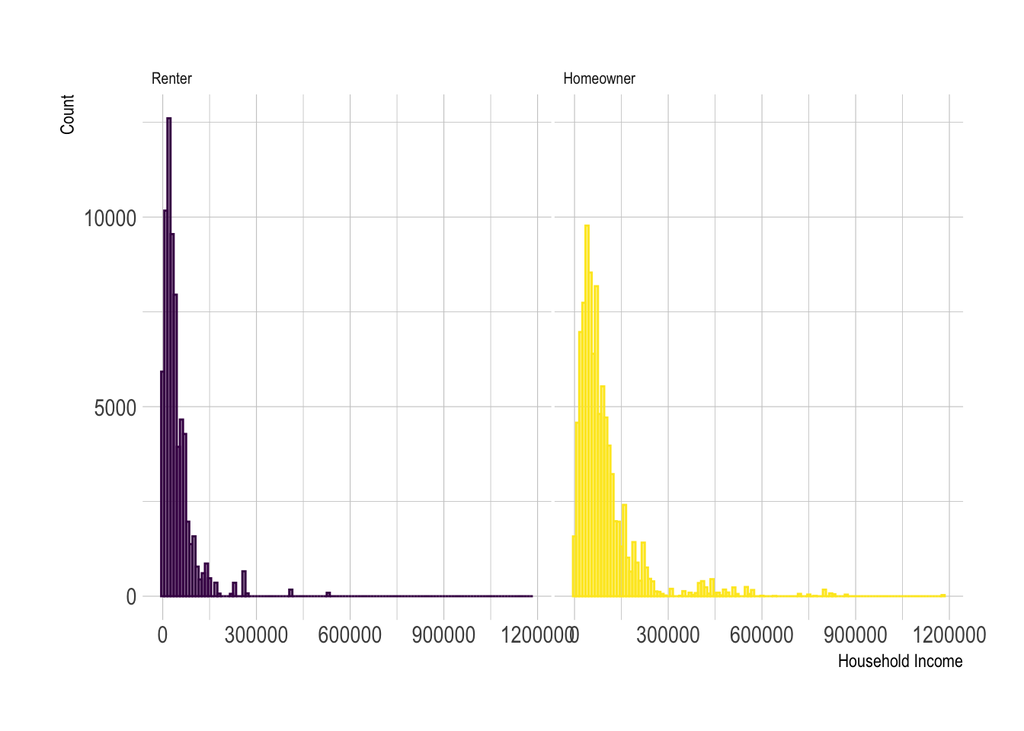

```r
#Female home-owners vs. female non-homeowners income
lville_2019 %>%
  filter(sex == 'female') %>%
  mutate(homeownership = replace(homeownership, homeownership == T, 'Homeowner'),
         homeownership = replace(homeownership, homeownership == F, 'Renter')) %>%
    func_plt_hist_updated( "homeownership")
```

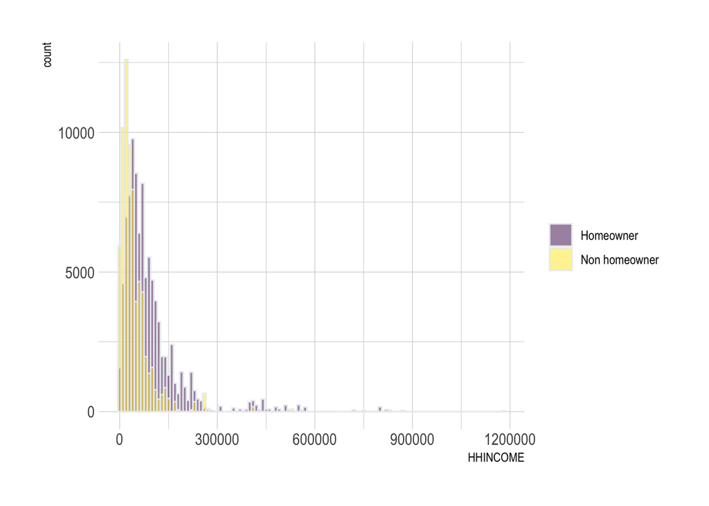

```r
#Female home-owners vs. female non-homeowners income, overlay
lville_2019 %>%
  filter(sex == 'female') %>%
  mutate(homeownership = replace(homeownership, homeownership == T, 'Homeowner'),
         homeownership = replace(homeownership, homeownership == F, 'Non homeowner')) %>%
    func_plt_hist_overlay( "homeownership")
```

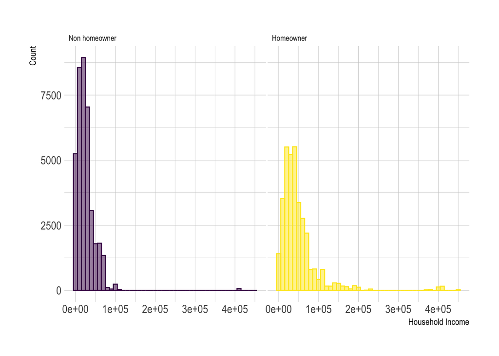

```r
#Female, Single home-owners vs. female, single, non-homeowners income
lville_2019 %>%
  filter(sex == 'female',
         earner_type == 'single_earner') %>%
  mutate(homeownership = replace(homeownership, homeownership == T, 'Homeowner'),
         homeownership = replace(homeownership, homeownership == F, 'Non homeowner')) %>%
    func_plt_hist_updated( "homeownership")
```

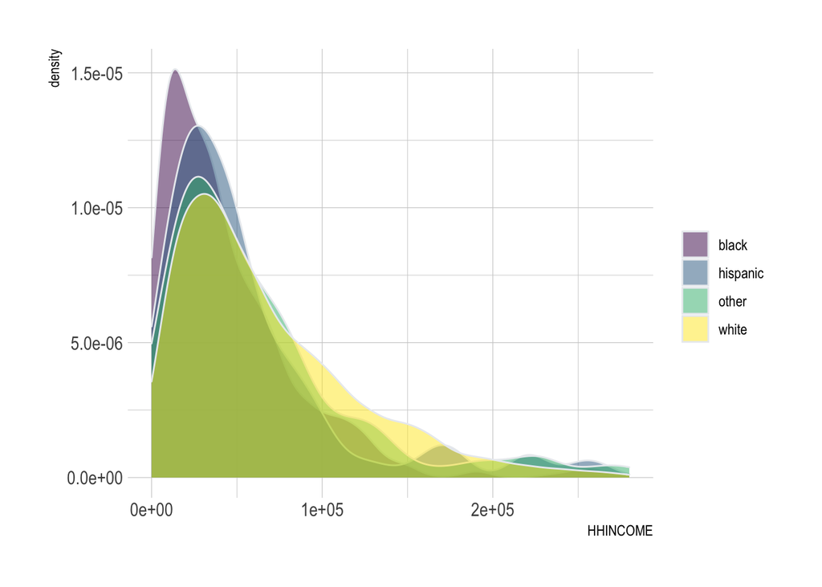

```r
#race by income overlay, truncated - tested with overlayed density plot...right path but could display info better...ideally can make this graph interactive so ppl can select a specfic group and then can also select specific percentiles...create df using suvery by demog function


census_microdata081122 %>%
  filter(year %in% 2017:2019,
    sex == 'female',
         HHINCOME <= cut_95) %>%
        func_plt_dens_overlay( "race")
```

```r
###come back to this...dont ignore it
df <- census_microdata081122 %>%
  filter(year %in% 2017:2019,
    sex == 'female')

survey_by_demog(df, type = 'mean', "HHINCOME")
```

# Homeownership

[figure not shown]

```r
p<-survey_by_demog(lville_2019, weight_var = "HHWT", 'homeownership') %>%
  filter(var_type == 'percent',
         race == 'total',
         sex != 'total')

ggplot(p, aes(x=sex, y=homeownership)) +
geom_bar(stat="identity", position=position_dodge())
```

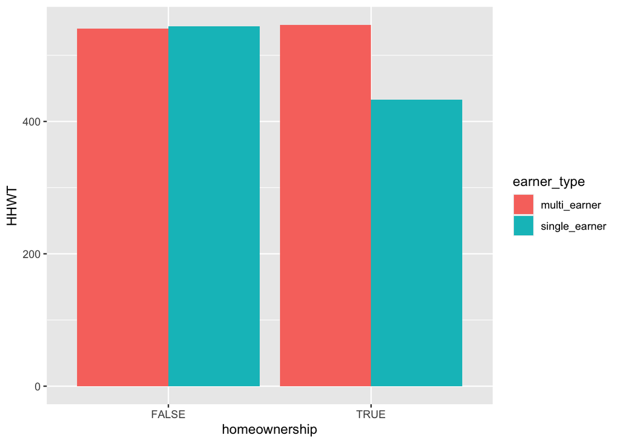

```r
lville_2019 %>%
  filter(sex == 'female') %>%

ggplot( aes(x=homeownership, y=HHWT, fill=earner_type, weights = HHWT)) +
geom_bar(stat="identity", position=position_dodge())
```

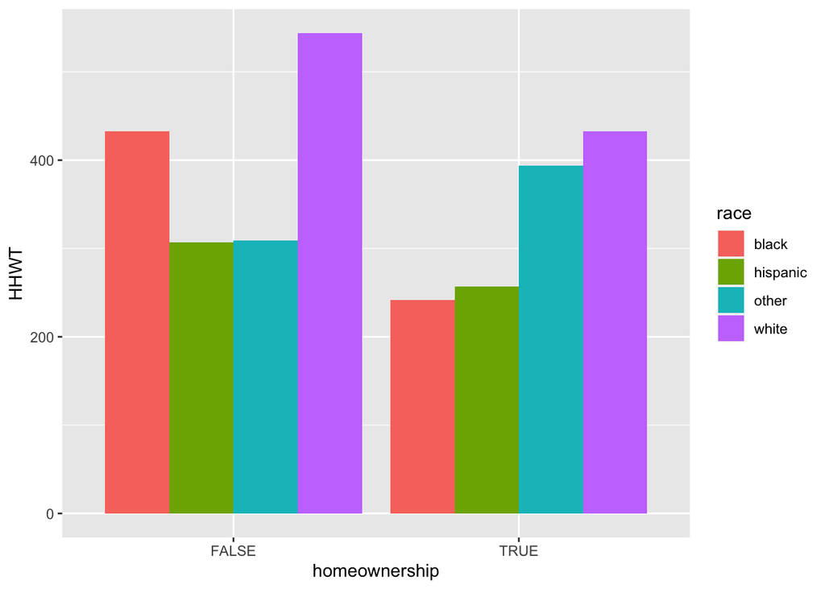

```r
lville_2019 %>%
    filter(sex == 'female',
           earner_type == 'single_earner') %>%

ggplot( aes(x=homeownership, y=HHWT, fill=race, weights = HHWT)) +
geom_bar(stat="identity", position=position_dodge())
```

# Education

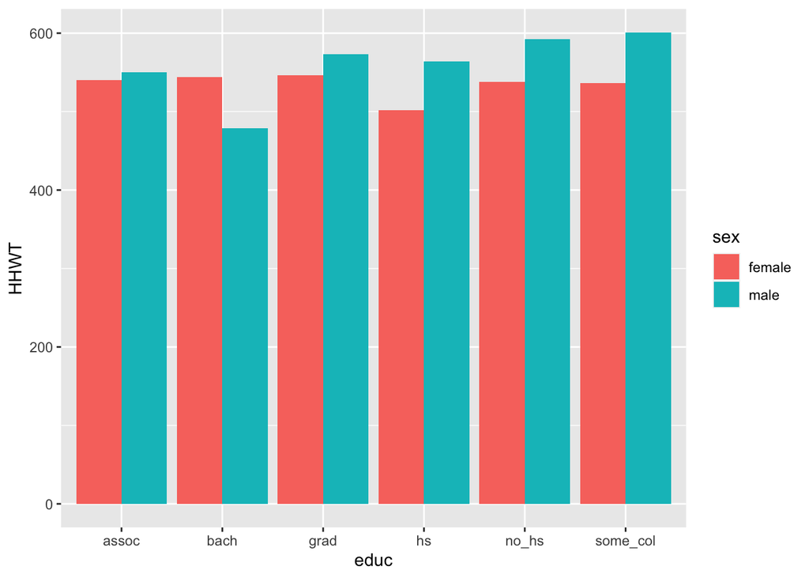

```r
lville_2019 %>%

ggplot( aes(x=educ, y=HHWT, fill=sex, weights = HHWT)) +
geom_bar(stat="identity", position=position_dodge())
```

```r
q <- lville_2019 %>%
  filter(sex == 'female') %>%
  group_by(race, educ) %>%
  summarize(n=sum(HHWT, na.rm = TRUE)) %>%
  mutate(total = sum(n),rate = n/sum(n)
  )
```

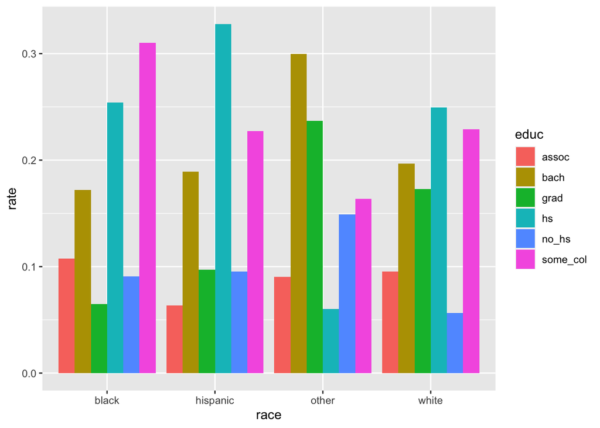

```r
  ggplot(q, aes(x=race, y=rate, fill=educ)) +
  geom_bar(stat="identity", position=position_dodge())
```

```r
# lville_2019 %>%
#   filter(sex == 'female') %>%
#
# ggplot( aes(x=educ, y=HHWT, fill=race, weights = HHWT)) +
# geom_bar(stat="identity", position=position_dodge())
```